# ÇOKLU DOĞRUSAL REGRESYON ANALİZİ

MELİS MERVE DOGANCAY

4/9/2021

## VERİ SETİ:

$\bullet$ ISLR paketinde yer alan Hitters veri seti ile çoklu doğrusal regresyon analizi yapılmıştır.

$\bullet$ Analizde kullanılan değişkenler:

Bağımlı değişken: Salary

Bağımsız değişken: CRuns, Walks, Years, Division, CRBI, CWalks, NewLeague, CatBat, PutOuts

```r
library(ISLR)
Hitters=na.omit(Hitters)
head(Hitters)
```

```
##                   AtBat Hits HmRun Runs RBI Walks Years CAtBat CHits
## -Alan Ashby         315   81     7   24  38    39    14   3449   835
## -Alvin Davis        479  130    18   66  72    76     3   1624   457
## -Andre Dawson       496  141    20   65  78    37    11   5628  1575
## -Andres Galarraga   321   87    10   39  42    30     2    396   101
## -Alfredo Griffin    594  169     4   74  51    35    11   4408  1133
## -Al Newman          185   37     1   23   8    21     2    214    42
##                   CHmRun CRuns CRBI CWalks League Division PutOuts Assists
## -Alan Ashby           69   321  414    375      N        W     632      43
## -Alvin Davis          63   224  266    263      A        W     880      82
## -Andre Dawson        225   828  838    354      N        E     200      11
## -Andres Galarraga     12    48   46     33      N        E     805      40
## -Alfredo Griffin      19   501  336    194      A        W     282     421
## -Al Newman             1    30    9     24      N        E      76     127
##                   Errors Salary NewLeague
## -Alan Ashby           10  475.0         N
## -Alvin Davis          14  480.0         A
## -Andre Dawson          3  500.0         N
## -Andres Galarraga      4   91.5         N
## -Alfredo Griffin      25  750.0         A
## -Al Newman             7   70.0         A
```

```r
# CRuns-11,Walks-6,Years-7,Division,CRBI-12,CWalks-13,NewLeague-20,CAtBat,PutOuts
data <- Hitters[,c(6, 7, 8, 11, 12, 13, 15, 16, 20, 19)]
rownames(data) <- c()
head(data)
```

```
##   Walks Years CAtBat CRuns CRBI CWalks Division PutOuts NewLeague Salary
## 1    39    14   3449   321  414    375        W     632         N  475.0
## 2    76     3   1624   224  266    263        W     880         A  480.0
## 3    37    11   5628   828  838    354        E     200         N  500.0
## 4    30     2    396    48   46     33        E     805         N   91.5
## 5    35    11   4408   501  336    194        W     282         A  750.0
## 6    21     2    214    30    9     24        E      76         A   70.0
```

$\bullet$ Veri seti %70’i eğitim ve %30’u test verisi olmak üzere ayrıldı.

```r
set.seed(123)
smp_size <- round(0.70 * nrow(data))
train_ind <- sample(nrow(data), size = smp_size, replace = FALSE)
train <- data[train_ind, ]
test <- data[-train_ind, ]

dim(train)
```

```
## [1] 184  10
```

```r
dim(test)
```

```
## [1] 79 10
```

## Matris Plot, Korelasyon matrisi ve korelasyon katsayılarına ilişkin p değerlerini matrisini elde ederek, %5 önem düzeyinde ## anlamlı korelasyon katsayılarını belirlenmesi:

```r
library(dplyr)
library(Hmisc)
cormatris <- as.matrix(train[,-c(7,9)])
matris1 <-rcorr(cormatris)
matris1$r
```

```
##             Walks      Years    CAtBat     CRuns      CRBI    CWalks
## Walks   1.0000000 0.13403070 0.2951302 0.3776355 0.3194478 0.4726044
## Years   0.1340307 1.00000000 0.9164487 0.8711206 0.8607106 0.8105461
## CAtBat  0.2951302 0.91644869 1.0000000 0.9806450 0.9572556 0.8903359
## CRuns   0.3776355 0.87112059 0.9806450 1.0000000 0.9580767 0.9208436
## CRBI    0.3194478 0.86071058 0.9572556 0.9580767 1.0000000 0.8847016
## CWalks  0.4726044 0.81054610 0.8903359 0.9208436 0.8847016 1.0000000
## PutOuts 0.3299292 0.04331099 0.1218142 0.1263307 0.1681641 0.1295375
## Salary  0.4946395 0.41654500 0.5729843 0.6327602 0.6204514 0.5608001
##            PutOuts    Salary
## Walks   0.32992923 0.4946395
## Years   0.04331099 0.4165450
## CAtBat  0.12181418 0.5729843
## CRuns   0.12633068 0.6327602
## CRBI    0.16816410 0.6204514
## CWalks  0.12953747 0.5608001
## PutOuts 1.00000000 0.2797524
## Salary  0.27975237 1.0000000
```

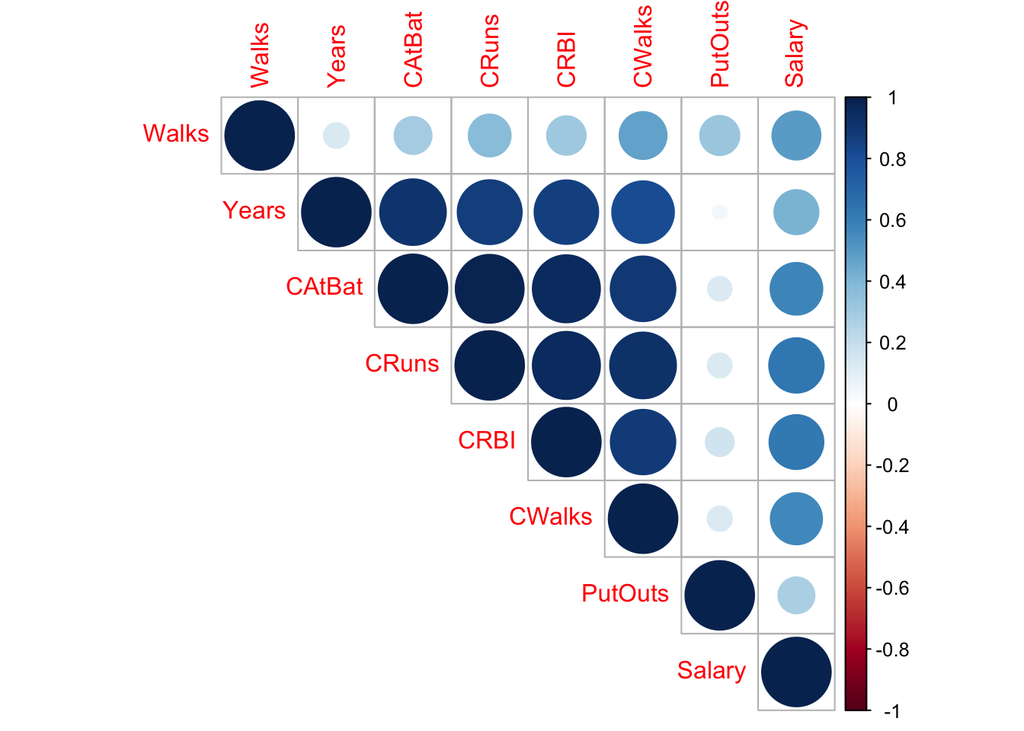

```r
library(corrplot)
corrplot(cor(cormatris), type = "upper")
```

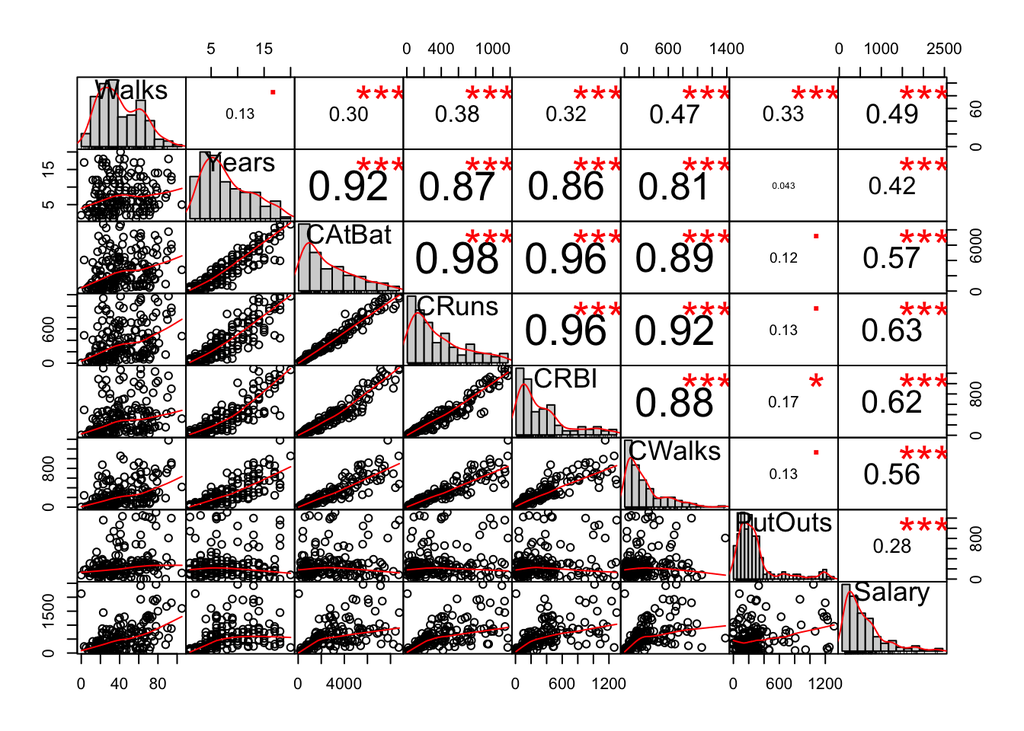

```r
PerformanceAnalytics::chart.Correlation(cormatris,histogram = T)
```

$\bullet$ Years, CatBat, CRuns, CRBI, CWalks değişkenleri arasında pozitif yönlü güçlü bir ilişki vardır. Dolayısıyla çoklu doğrusal bağlantı sorunu beklenmektedir.

```r
matris1$P
```

```
##                Walks        Years       CAtBat        CRuns         CRBI
## Walks             NA 6.969558e-02 4.761757e-05 1.259916e-07 9.868250e-06
## Years   6.969558e-02           NA 0.000000e+00 0.000000e+00 0.000000e+00
## CAtBat  4.761757e-05 0.000000e+00           NA 0.000000e+00 0.000000e+00
## CRuns   1.259916e-07 0.000000e+00 0.000000e+00           NA 0.000000e+00
## CRBI    9.868250e-06 0.000000e+00 0.000000e+00 0.000000e+00           NA
## CWalks  1.256639e-11 0.000000e+00 0.000000e+00 0.000000e+00 0.000000e+00
## PutOuts 4.794136e-06 5.593756e-01 9.950718e-02 8.748658e-02 2.250008e-02
## Salary  9.561241e-13 4.070794e-09 0.000000e+00 0.000000e+00 0.000000e+00
##               CWalks      PutOuts       Salary
## Walks   1.256639e-11 4.794136e-06 9.561241e-13
## Years   0.000000e+00 5.593756e-01 4.070794e-09
## CAtBat  0.000000e+00 9.950718e-02 0.000000e+00
## CRuns   0.000000e+00 8.748658e-02 0.000000e+00
## CRBI    0.000000e+00 2.250008e-02 0.000000e+00
## CWalks            NA 7.967949e-02 0.000000e+00
## PutOuts 7.967949e-02           NA 1.200806e-04
## Salary  0.000000e+00 1.200806e-04           NA
```

$\bullet$ Bağımlı değişken Salary ile bağımsız değişkenlerin korelasyonu anlamlıdır.

## Çoklu doğrusal regresyon modelini elde edilmesi ve model geçerliliğinin sıfır ve alternatif hipotezleri belirtilerek %5 önem düzeyinde test edilmesi:

```r
model1 <- lm(Salary~Walks+Years+CAtBat+CRuns+CRBI+CWalks+Division+PutOuts+NewLeague, data = train)
summary(model1)
```

```
##
## Call:
## lm(formula = Salary ~ Walks + Years + CAtBat + CRuns + CRBI +
##     CWalks + Division + PutOuts + NewLeague, data = train)
##
## Residuals:
##     Min      1Q  Median      3Q     Max
## -803.91 -176.81   -2.54  155.23 1925.88
##
## Coefficients:
##               Estimate Std. Error t value Pr(>|t|)
## (Intercept)  116.51658   86.03901   1.354 0.177419
## Walks          5.16882    1.47090   3.514 0.000563 ***
## Years        -16.50774   14.59295  -1.131 0.259522
## CAtBat        -0.18520    0.08067  -2.296 0.022878 *
## CRuns          2.17272    0.54671   3.974 0.000103 ***
## CRBI           0.79763    0.27953   2.853 0.004850 **
## CWalks        -0.86064    0.26864  -3.204 0.001614 **
## DivisionW   -138.64609   49.00632  -2.829 0.005216 **
## PutOuts        0.15030    0.09087   1.654 0.099928 .
## NewLeagueN    98.63966   49.18452   2.006 0.046459 *
## ---
## Signif. codes:  0 '***' 0.001 '**' 0.01 '*' 0.05 '.' 0.1 ' ' 1
##
## Residual standard error: 319.8 on 174 degrees of freedom
## Multiple R-squared:  0.5892, Adjusted R-squared:  0.568
## F-statistic: 27.73 on 9 and 174 DF,  p-value: < 2.2e-16
```

$\bullet$ Değişkenlerden “Years” ve “PutOuts” %5 önem düzeyinde anlamlı değildir. Diğer değişkenlerin t istatistiklerinin olasılık değeri 0.05’den küçük olduğundan anlamlı gözükmektedir.

Walks $H_{0}: \beta_{1} = 0\quad H_{1}: \beta_{1} \neq 0$ p = 0.000563 $H_{0}$ hipotezi reddedilir. Değişken anlamlıdır.

Years $H_{0}: \beta_{2} = 0\quad H_{1}: \beta_{2} \neq 0$ p = 0.259522 $H_{0}$ hipotezi reddedilemez. Değişken anlamlı değildir.

CRuns $H_{0}: \beta_{4} = 0\quad H_{1}: \beta_{4} \neq 0$ p = 0.000103 $H_{0}$ hipotezi reddedilir. Değişken anlamlıdır.

CRBI $H_{0}: \beta_{5} = 0\quad H_{1}: \beta_{5} \neq 0$ p = 0.004850 $H_{0}$ hipotezi reddedilir. Değişken anlamlıdır.

CWalks $H_{0}: \beta_{6} = 0\quad H_{1}: \beta_{6} \neq 0$ p = 0.001614 $H_{0}$ hipotezi reddedilir. Değişken anlamlıdır.

DivisionW $H_{0}: \beta_{7} = 0\quad H_{1}: \beta_{7} \neq 0$ p = 0.005216 $H_{0}$ hipotezi reddedilir. Değişken anlamlıdır.

## VIF değerlerinin elde edilmesi:

```r
car::vif(model1)
```

```
##     Walks     Years    CAtBat     CRuns      CRBI    CWalks  Division
##  1.940138  8.416346 55.930008 51.977872 14.395539  8.388450  1.074037
##   PutOuts NewLeague
##  1.223284  1.059235
```

$\bullet$ Years, CatBat, CRuns, CRBI, CWalks değişkenlerinin VIF değerleri 5’den büyük olduğundan çoklu doğrusal bağlantı sorunu mevcuttur.

## En iyi olası alt küme değişken seçim yöntemini uygulayarak alternatif iki model belirlenmesi:

```r
olsrr::ols_step_best_subset(model1)
```

```
##                            Best Subsets Regression
## ------------------------------------------------------------------------------
## Model Index    Predictors
## ------------------------------------------------------------------------------
##      1         CRuns
##      2         Walks CRBI
##      3         Walks CRBI Division
##      4         Walks Years CRBI Division
##      5         Walks CAtBat CRuns CRBI CWalks
##      6         Walks CAtBat CRuns CRBI CWalks Division
##      7         Walks CAtBat CRuns CRBI CWalks Division NewLeague
##      8         Walks CAtBat CRuns CRBI CWalks Division PutOuts NewLeague
##      9         Walks Years CAtBat CRuns CRBI CWalks Division PutOuts NewLeague
## ------------------------------------------------------------------------------
##
##                                                           Subsets Regression Summary
## -----------------------------------------------------------------------------------------------------------------------------------------------
##                        Adj.        Pred
## Model    R-Square    R-Square    R-Square     C(p)         AIC         SBIC          SBC          MSEP            FPE          HSP        APC
## -----------------------------------------------------------------------------------------------------------------------------------------------
##   1        0.4004      0.3971      0.3794    73.9868    2709.9781    2186.5546    2719.6229    144280.5295    144263.3889    788.4650    0.6128
##   2        0.4828      0.4771      0.4526    41.0682    2684.7646    2161.5835    2697.6244    125827.2660    125789.8953    687.6215    0.5343
##   3        0.5093      0.5011      0.4749    31.8563    2677.0980    2153.9841    2693.1727    120721.3821    120656.8443    659.7189    0.5125
##   4        0.5324      0.5220      0.4946    24.0544    2670.2099    2147.3208    2689.4995    116320.9852    116224.2526    635.6716    0.4937
##   5        0.5482      0.5355      0.4961    19.3953    2665.9169    2143.2809    2688.4215    113680.1498    113545.0976    621.2399    0.4823
##   6        0.5669      0.5522      0.5114    13.4571    2660.1226    2137.9947    2685.8421    110203.4450    110026.7005    602.2404    0.4674
##   7        0.5791      0.5624      0.5202    10.2869    2656.8627    2135.2040    2685.7971    108321.6712    108096.4702    591.9569    0.4592
##   8        0.5862      0.5673      0.5192     9.2796    2655.7326    2134.4537    2687.8819    107718.6075    107437.0738    588.6612    0.4564
##   9        0.5892      0.5680       0.518    10.0000    2656.3843    2135.3578    2691.7486    108168.4083    107821.4470    591.1193    0.4580
## -----------------------------------------------------------------------------------------------------------------------------------------------
## AIC: Akaike Information Criteria
##  SBIC: Sawa's Bayesian Information Criteria
##  SBC: Schwarz Bayesian Criteria
##  MSEP: Estimated error of prediction, assuming multivariate normality
##  FPE: Final Prediction Error
##  HSP: Hocking's Sp
##  APC: Amemiya Prediction Criteria
```

$\bullet$ Çoklu doğrusal bağlantı sorunu olmayan ve cp değeri en az yanlı olan, adjusted r-squared ve r-squared birbirine yakın, AIC ve SBIC mümkün olan en düşük, parametrelerin p-değerlerinin %5 önem düzeyinde anlamlı olduğu mümkün olan en iyi model aşağıdaki model çıkmıştır.

```r
model2 <- lm(Salary~Walks+Years+CRBI+Division  , data = train)
summary(model2)
```

```
##
## Call:
## lm(formula = Salary ~ Walks + Years + CRBI + Division, data = train)
##
## Residuals:
##      Min       1Q   Median       3Q      Max
## -1023.61  -202.09   -28.17   166.74  1942.20
##
## Coefficients:
##              Estimate Std. Error t value Pr(>|t|)
## (Intercept)  241.4685    80.4514   3.001  0.00307 **
## Walks          5.6794     1.2341   4.602  7.9e-06 ***
## Years        -32.3688    10.8752  -2.976  0.00332 **
## CRBI           1.2005     0.1665   7.212  1.5e-11 ***
## DivisionW   -165.6370    50.2623  -3.295  0.00118 **
## ---
## Signif. codes:  0 '***' 0.001 '**' 0.01 '*' 0.05 '.' 0.1 ' ' 1
##
## Residual standard error: 336.4 on 179 degrees of freedom
## Multiple R-squared:  0.5324, Adjusted R-squared:  0.522
## F-statistic: 50.96 on 4 and 179 DF,  p-value: < 2.2e-16
```

```r
car::vif(model2)
```

```
##    Walks    Years     CRBI Division
## 1.234341 4.224569 4.613892 1.021101
```

$\bullet$ Alternatif modelimiz aynı kriterler değerlendirilerek 8 değişkenli model olacaktır.

```r
model3 <- lm(Salary~Walks+CAtBat+CRuns+CRBI+CWalks+Division+PutOuts+NewLeague, data = train)
summary(model3)
```

```
##
## Call:
## lm(formula = Salary ~ Walks + CAtBat + CRuns + CRBI + CWalks +
##     Division + PutOuts + NewLeague, data = train)
##
## Residuals:
##     Min      1Q  Median      3Q     Max
## -787.64 -187.77   -8.15  147.84 1947.81
##
## Coefficients:
##               Estimate Std. Error t value Pr(>|t|)
## (Intercept)   58.95047   69.43150   0.849 0.397016
## Walks          5.63071    1.41422   3.981 0.000100 ***
## CAtBat        -0.23943    0.06492  -3.688 0.000302 ***
## CRuns          2.37143    0.51813   4.577 8.92e-06 ***
## CRBI           0.81163    0.27948   2.904 0.004158 **
## CWalks        -0.94995    0.25698  -3.697 0.000292 ***
## DivisionW   -133.88839   48.86451  -2.740 0.006781 **
## PutOuts        0.15723    0.09074   1.733 0.084898 .
## NewLeagueN   102.01806   49.13298   2.076 0.039322 *
## ---
## Signif. codes:  0 '***' 0.001 '**' 0.01 '*' 0.05 '.' 0.1 ' ' 1
##
## Residual standard error: 320 on 175 degrees of freedom
## Multiple R-squared:  0.5862, Adjusted R-squared:  0.5673
## F-statistic: 30.99 on 8 and 175 DF,  p-value: < 2.2e-16
```

```r
car::vif(model3)
```

```
##     Walks    CAtBat     CRuns      CRBI    CWalks  Division   PutOuts
##  1.790636 36.172020 46.611669 14.367327  7.663762  1.066126  1.217733
## NewLeague
##  1.055330
```

$\bullet$ Alternatif modelde çoklu doğrusal bağlantı sorunu vardır.

## Alternatif modellerin tahmin performansını test seti üzerinde PRESS değerini dikkate alarak incelenmesi ve en uygun modele karar verilmesi:

```r
predictions2=predict(model2,test)
predictions3=predict(model3,test)
PRESS2=caret::RMSE(predictions2,test$Salary)
PRESS3=caret::RMSE(predictions3,test$Salary)
PRESS2
```

```
## [1] 364.5544
```

```r
PRESS3
```

```
## [1] 360.7396
```

$\bullet$ 8 değişkenli model3’ün PRESS değeri daha düşük çıkmıştır. Ancak çoklu doğrusal bağlantı sorunu olduğundan model2 ile analize devam edilecektir.

## Hipotezleri yazarak, hataların normal dağıldığı varsayımını grafikle ve uygun istatistiksel test ile kontrol edilmesi: (α=0.05)

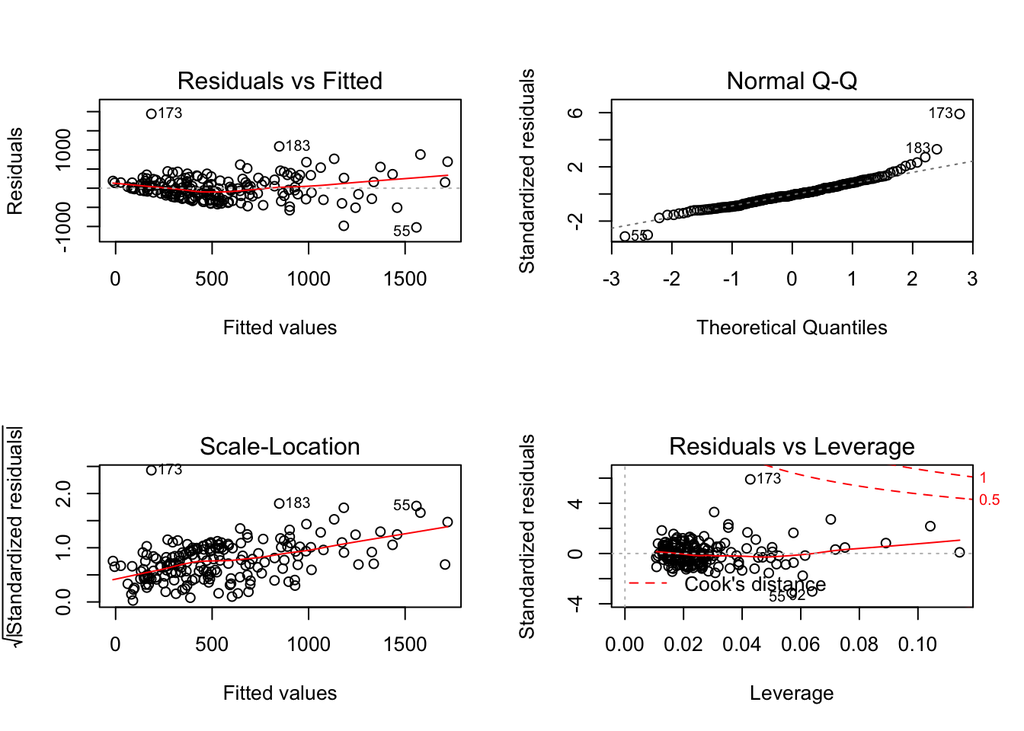

```r
par(mfrow=c(2,2))
plot(model2)
```

$\bullet$ Normallik varsayımı: $H_{0}$: Hatalar normal dağılım varsayımına uyar. $H_{1}$: Hatalar normal dağılım varsayımına uymaz.

```r
nortest::lillie.test(residuals(model2))
```

```
##
##  Lilliefors (Kolmogorov-Smirnov) normality test
##
## data:  residuals(model2)
## D = 0.072375, p-value = 0.0201
```

$\bullet$ p=0.02<0.05 olduğundan $H_{0}$ reddedildi. Artıkların normaliği varsayımı sağlanamamştır.

## Hipotezleri yazarak, hataların sabit varyanslı olup olmadığını grafikle ve uygun istatistiksel test ile kontrol edilmesi: (α=0.05)

$\bullet$ $H_{0}$: Hatalar sabit varyanslıdır. $H_{1}$: Hatalar sabit varyanslı değildir.

```r
lmtest::bptest(model2)
```

```
##
##  studentized Breusch-Pagan test
##
## data:  model2
## BP = 11.444, df = 4, p-value = 0.022
```

$\bullet$ p=0.02<0.05 olduğundan $H_{0}$ reddedildi. Yani varyans homojenliği sağlanamamıştır. Sabit varyanslılık varsayımı sağlanamamıştır.

## Uç değer ve etkin gözlem olup olmadığını grafiklerle ve ilgili değerlerle belirlenmesi:

$\bullet$ Uç Değerler:

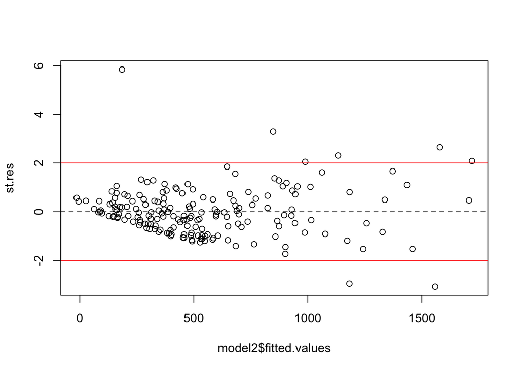

```r
st.res <- model2$residuals / sd(model2$residuals)
plot(model2$fitted.values, st.res)
abline(h = 0, lty = 2)
abline(h = c(-2,2), col = "red")
```

```r
which(abs(st.res)>2)
```

```
##  92  63 127 200  55  77 183 173
##  16  52  78 122 126 132 155 175
```

$\bullet$ Etkin değerler(Cooks Distance):

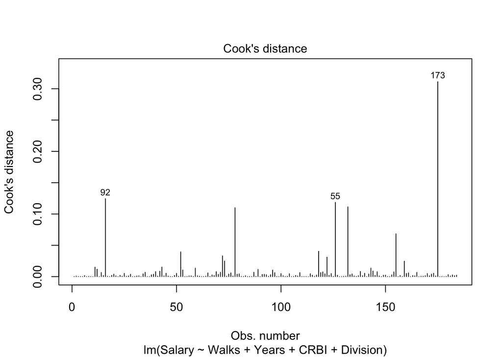

```r
cutoff <- 4/(length(train$Salary)-5)
plot(model2, which=4, cook.levels=cutoff)
```

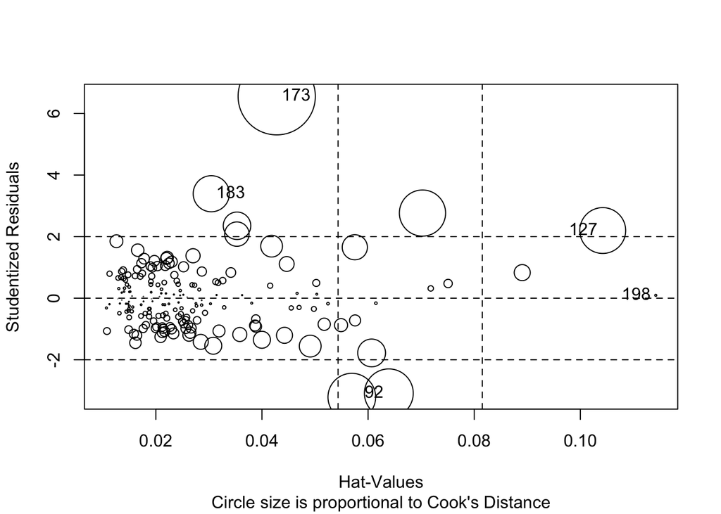

```
##         StudRes        Hat        CookD
## 92  -3.08956021 0.06390815 0.1243963804
## 127  2.19760281 0.10421732 0.1100202117
## 198  0.09265061 0.11421509 0.0002226045
## 183  3.39298221 0.03044748 0.0682949792
## 173  6.55737486 0.04277916 0.3112952739
```

```r
car::influencePlot(model2,
              id.method="identify", sub="Circle size is proportional to Cook's Distance" )
```

$\bullet$ Hat-Value ve Cook’s Distance kriterlerine bakılarak sorun yaratacak gözlemler elde edilmiştir. Ve bu gözlemler modelden çıkartılmalıdır.

```r
bad_lev <- which(abs(st.res)>2 & hatvalues(model2)> 2*mean(hatvalues(model2)))
bad_lev
```

```
##  92 127  55  77
##  16  78 126 132
```

$\bullet$ Bu bulunan gözlemlerden uç nokta,kötü kaldıraç ve etkin gözlem olanlar çıkartılarak,yeni model oluşturulacaktır.Varsayımlar kontrol edilecektir.

```r
data_cleaned <- train[-bad_lev,]
set.seed(123)
smp_size2 <- round(0.7 * nrow(data_cleaned))
train_ind2 <- sample(x = nrow(data_cleaned),size = smp_size2,replace = F)
train2 <- data_cleaned[train_ind2,]
test2 <- data_cleaned[-train_ind2,]
```

$\bullet$ Belirlediğimiz gözlemleri çıkardıktan sonra modeli tekrar kuracak ve varsayımları kontrol edeceğiz.

```r
model4 <- lm(Salary~Walks+Years+CRBI+Division  , data = train2)
summary(model4)
```

```
##
## Call:
## lm(formula = Salary ~ Walks + Years + CRBI + Division, data = train2)
##
## Residuals:
##     Min      1Q  Median      3Q     Max
## -630.05 -178.23  -43.32  139.90 1996.95
##
## Coefficients:
##              Estimate Std. Error t value Pr(>|t|)
## (Intercept)  166.2882    95.8222   1.735   0.0852 .
## Walks          6.2427     1.4408   4.333 3.06e-05 ***
## Years        -21.8529    15.3263  -1.426   0.1565
## CRBI           1.1144     0.2353   4.737 5.97e-06 ***
## DivisionW   -142.7653    60.9099  -2.344   0.0207 *
## ---
## Signif. codes:  0 '***' 0.001 '**' 0.01 '*' 0.05 '.' 0.1 ' ' 1
##
## Residual standard error: 336.2 on 121 degrees of freedom
## Multiple R-squared:  0.5314, Adjusted R-squared:  0.5159
## F-statistic:  34.3 on 4 and 121 DF,  p-value: < 2.2e-16
```

```r
nortest::lillie.test(residuals(model4))
```

```
##
##  Lilliefors (Kolmogorov-Smirnov) normality test
##
## data:  residuals(model4)
## D = 0.10274, p-value = 0.002345
```

```r
lmtest::bptest(model4)
```

```
##
##  studentized Breusch-Pagan test
##
## data:  model4
## BP = 5.004, df = 4, p-value = 0.2869
```

$\bullet$ p=0.28>0.05 olduğundan $H_{0}$ reddedilmedi. Yani varyans homojenliği sağlanamıştır.. Sabit varyanslılık varsayımı sağlanabilmiştir.

$\bullet$ p=0.002<0.05 olduğundan $H_{0}$ reddedildi. Artıkların normaliği varsayımı sağlanamamştır.

## Modelde yer alan değişkenlere ait katsayının yorumlanaması:

```r
summary(model4)
```

```
##
## Call:
## lm(formula = Salary ~ Walks + Years + CRBI + Division, data = train2)
##
## Residuals:
##     Min      1Q  Median      3Q     Max
## -630.05 -178.23  -43.32  139.90 1996.95
##
## Coefficients:
##              Estimate Std. Error t value Pr(>|t|)
## (Intercept)  166.2882    95.8222   1.735   0.0852 .
## Walks          6.2427     1.4408   4.333 3.06e-05 ***
## Years        -21.8529    15.3263  -1.426   0.1565
## CRBI           1.1144     0.2353   4.737 5.97e-06 ***
## DivisionW   -142.7653    60.9099  -2.344   0.0207 *
## ---
## Signif. codes:  0 '***' 0.001 '**' 0.01 '*' 0.05 '.' 0.1 ' ' 1
##
## Residual standard error: 336.2 on 121 degrees of freedom
## Multiple R-squared:  0.5314, Adjusted R-squared:  0.5159
## F-statistic:  34.3 on 4 and 121 DF,  p-value: < 2.2e-16
```

$\bullet$ Diğer bağımsız değişkenler modelde ve sabitken Walks değişkenindeki 1 birimlik artış ortalama Salary değişkenini 6.2427 artırır.

$\bullet$ Diğer bağımsız değişkenler modelde ve sabitken CRBI değişkenindeki 1 birimlik artış ortalama Salary değişkenini 1.1144 artırır.

$\bullet$ Diğer bağımsız değişkenler modelde ve sabitken Years değişkenindeki 1 birimlik artış ortalama Salary değişkenini 21.8529 azaltır.

$\bullet$ Diğer bağımsız değişkenler modelde ve sabitken Division değişkeni W olduğundaki 1 birimlik artış ortalama Salary değişkenini 142.7653 azaltır.